# ME MA exploration for paper

Molly Lewis

2017-11-25

## Summary of coded data

```
##          study_ID                            short_cite expt_num
##  merriman1989:17   Merriman et al. (1989)         :17   1  :108
##  frank2016   :12   Frank et al. (2016)            :12   1-2:  1
##  gollek2016  :10   Gollek & Doherty (2016)        :10   2  : 25
##  jarvis2004  : 9   Jarvis et al. (2004)           : 9   2a :  4
##  markman2003 : 8   Markman, Wasow, & Hansen (2003): 8   2b :  2
##  merriman1991: 8   Merriman & Schuster (1991)     : 8   3  : 15
##  (Other)     :93   (Other)                        :93   4  :  2
##       response_mode           dependent_measure           native_lang
##  behavior    :131   looking_time_change: 10     American English:42
##  eye-tracking: 26   target_selection   :147     English         :32
##                                                 British English :12
##                                                 Canadian English: 5
##                                                 German Germany  : 5
##                                                 (Other)         :21
##                                                 NA's            :40
##                               infant_type       n_1
##  typical                            :135   Min.   : 5.00
##  bilingual                          : 10   1st Qu.:15.00
##  ASD                                :  4   Median :16.00
##  specific language imparement (SLI) :  3   Mean   :19.06
##  trilingual                         :  2   3rd Qu.:22.00
##  deaf/hard-of-hearing preschoolers w:  1   Max.   :72.00
##  (Other)                            :  2
##    mean_age_1          x_1               x_2              SD_1
##  Min.   : 445.2   Min.   :-0.0300   Min.   :0.0000   Min.   :0.02196
##  1st Qu.: 730.5   1st Qu.: 0.5308   1st Qu.:0.5000   1st Qu.:0.16606
##  Median : 974.0   Median : 0.6738   Median :0.5000   Median :0.23000
##  Mean   :1133.3   Mean   : 0.6538   Mean   :0.4518   Mean   :0.27439
##  3rd Qu.:1461.0   3rd Qu.: 0.8295   3rd Qu.:0.5000   3rd Qu.:0.29866
##  Max.   :3926.4   Max.   : 0.9860   Max.   :0.5000   Max.   :2.08000
##                   NA's   :15        NA's   :16       NA's   :25
##        t                d               d_var              object_stimulus
##  Min.   :-3.140   Min.   :-0.9467   Min.   :0.02801   digital      :35
##  1st Qu.: 1.555   1st Qu.: 0.2436   1st Qu.:0.10614   objects      :76
##  Median : 3.645   Median : 1.0790   Median :0.13219   objects/paper: 1
##  Mean   : 5.113   Mean   : 1.4551   Mean   :0.17196   paper        :45
##  3rd Qu.: 5.168   3rd Qu.: 1.8525   3rd Qu.:0.20219
##  Max.   :31.700   Max.   :11.4100   Max.   :0.86701
##  NA's   :119      NA's   :93        NA's   :104
```

[output cut: 25 more lines]

```
##  merriman:48   Min.   :-0.9467   Min.   :0.01435   Min.   : 14.63
##  framkm  :12   1st Qu.: 0.2887   1st Qu.:0.06383   1st Qu.: 24.00
##  gollek  :10   Median : 0.8734   Median :0.08558   Median : 32.00
##  markman :10   Mean   : 1.3293   Mean   :0.22861   Mean   : 37.23
##  estis   : 7   3rd Qu.: 1.8500   3rd Qu.:0.17323   3rd Qu.: 48.00
##  horst   : 6   Max.   : 9.3462   Max.   :2.97835   Max.   :129.00
##  (Other) :64
##       year
##  Min.   :1988
##  1st Qu.:1998
##  Median :2004
##  Mean   :2005
##  3rd Qu.:2014
##  Max.   :2017
##
```

infant types

| infant_type2 | n |
| --- | --- |
| ASD | 4 |
| bilingual | 10 |
| deaf/hard-of-hearing | 1 |
| DS | 1 |
| late_talkers | 1 |
| SLI | 3 |
| trilingual | 2 |
| typical | 135 |

trial types

| ME_trial_type | n |
| --- | --- |
| FN | 136 |
| NN | 21 |

production vocab

| !is.na(mean_production_vocab) | infant_type | n |
| --- | --- | --- |
| FALSE | ASD | 3 |
| FALSE | bilingual | 8 |
| FALSE | late_talkers | 1 |
| FALSE | specific language imparement (SLI) | 3 |
| FALSE | trilingual | 1 |
| FALSE | typical | 112 |
| TRUE | ASD | 1 |
| TRUE | bilingual | 2 |
| TRUE | deaf/hard-of-hearing preschoolers w | 1 |
| TRUE | DS | 1 |
| TRUE | trilingual | 1 |
| TRUE | typical | 23 |

comprehension vocab

| !is.na(mean_comprehension_vocab) | n |
| --- | --- |
| FALSE | 136 |
| TRUE | 21 |

## Fail-safe-N

| dataset | fsn_string |
| --- | --- |
| mutex | 20713 |

## Funnel plot

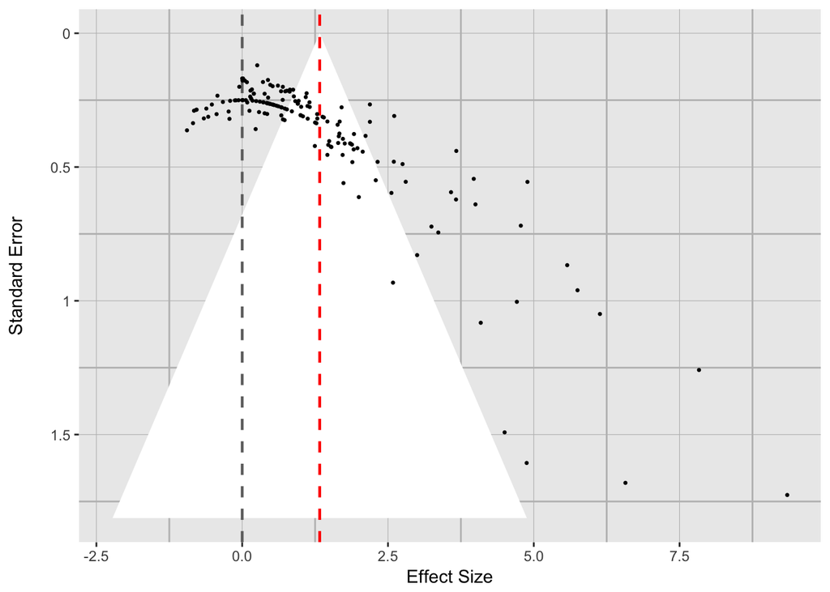

With age and response mode and trial type moderators

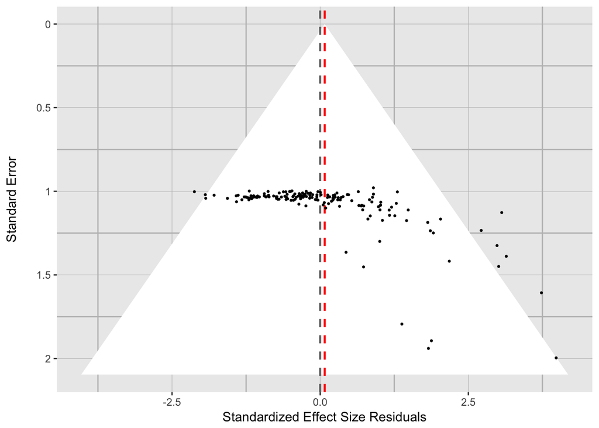

Eggers test

| dataset | egg.random.z | egg.random.p |
| --- | --- | --- |
| mutex | 17.31427 | 0 |

Evidence for skew. Lots of heterogenity.

## P-curve

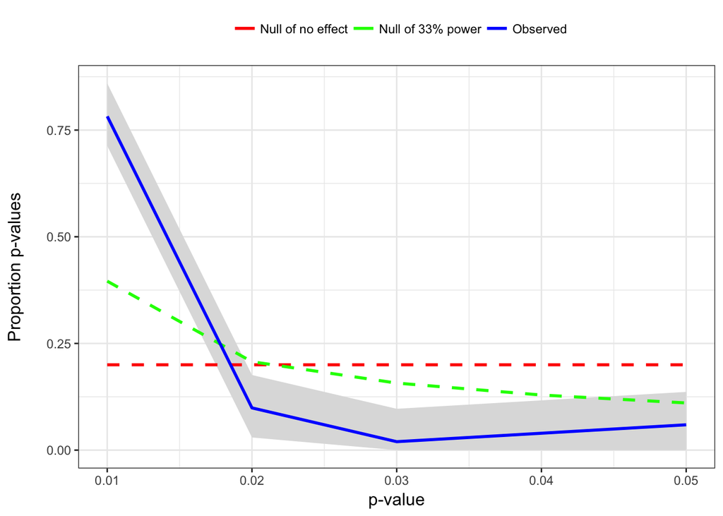

Stouffer test

| pp.measure | Z.pp | p.Z.pp | sig |
| --- | --- | --- | --- |
| ppr.full | -27.16405 | 0 | TRUE |

## MA models

### Simple (no moderators)

```
##
## Multivariate Meta-Analysis Model (k = 157; method: REML)
##
##    logLik   Deviance        AIC        BIC       AICc
## -437.5768   875.1535   879.1535   885.2532   879.2319
##
## Variance Components:
##
##             estim    sqrt  nlvls  fixed      factor
## sigma^2    0.6353  0.7970     44     no  short_cite
##
## Test for Heterogeneity:
## Q(df = 156) = 1379.1191, p-val < .0001
##
## Model Results:
##
## estimate      se    zval    pval   ci.lb   ci.ub
##   1.0576  0.1256  8.4235  <.0001  0.8115  1.3037  ***
##
## ---
## Signif. codes:  0 '***' 0.001 '**' 0.01 '*' 0.05 '.' 0.1 ' ' 1
```

### ME_trial type

```
##
## Multivariate Meta-Analysis Model (k = 157; method: REML)
##
##    logLik   Deviance        AIC        BIC       AICc
## -427.1495   854.2990   860.2990   869.4292   860.4579
##
## Variance Components:
##
##             estim    sqrt  nlvls  fixed      factor
## sigma^2    0.8893  0.9430     44     no  short_cite
##
## Test for Residual Heterogeneity:
## QE(df = 155) = 1371.6365, p-val < .0001
##
## Test of Moderators (coefficient(s) 2):
## QM(df = 1) = 21.5920, p-val < .0001
##
## Model Results:
##
##                  estimate      se     zval    pval    ci.lb    ci.ub
## intrcpt            1.2065  0.1498   8.0569  <.0001   0.9130   1.5000  ***
## ME_trial_typeNN   -0.7107  0.1529  -4.6467  <.0001  -1.0105  -0.4109  ***
##
## ---
## Signif. codes:  0 '***' 0.001 '**' 0.01 '*' 0.05 '.' 0.1 ' ' 1
```

### Age

```
##
## Multivariate Meta-Analysis Model (k = 157; method: REML)
##
##    logLik   Deviance        AIC        BIC       AICc
## -356.4074   712.8148   720.8148   732.9626   721.0833
##
## Variance Components:
##
##             estim    sqrt  nlvls  fixed      factor
## sigma^2    0.5954  0.7716     44     no  short_cite
##
## Test for Residual Heterogeneity:
## QE(df = 154) = 1121.3202, p-val < .0001
##
## Test of Moderators (coefficient(s) 2:3):
## QM(df = 2) = 160.4053, p-val < .0001
##
## Model Results:
##
##                  estimate      se     zval    pval    ci.lb    ci.ub
## intrcpt           -0.1419  0.1664  -0.8528  0.3938  -0.4681   0.1842
## mean_age           0.0369  0.0031  11.9606  <.0001   0.0309   0.0430  ***
## ME_trial_typeNN   -0.9187  0.1499  -6.1285  <.0001  -1.2125  -0.6249  ***
##
## ---
## Signif. codes:  0 '***' 0.001 '**' 0.01 '*' 0.05 '.' 0.1 ' ' 1
```

Age is reliable, controling for ME_trial_type

### Vocab

(we don’t have production scores for any NN trials)

```
##
## Multivariate Meta-Analysis Model (k = 29; method: REML)
##
##   logLik  Deviance       AIC       BIC      AICc
## -27.8365   55.6730   61.6730   65.5605   62.7165
##
## Variance Components:
##
##             estim    sqrt  nlvls  fixed      factor
## sigma^2    0.4073  0.6382     11     no  short_cite
##
## Test for Residual Heterogeneity:
## QE(df = 27) = 131.2620, p-val < .0001
##
## Test of Moderators (coefficient(s) 2):
## QM(df = 1) = 8.6147, p-val = 0.0033
##
## Model Results:
##
##                        estimate      se    zval    pval    ci.lb   ci.ub
## intrcpt                  0.4909  0.2619  1.8744  0.0609  -0.0224  1.0041
## mean_production_vocab    0.0024  0.0008  2.9351  0.0033   0.0008  0.0039
##
## intrcpt                 .
## mean_production_vocab  **
##
## ---
## Signif. codes:  0 '***' 0.001 '**' 0.01 '*' 0.05 '.' 0.1 ' ' 1
```

Vocab is reliable

### Age + Vocab

#### Plots

Correlation between age and vocab:

| estimate | statistic | p.value | parameter | conf.low | conf.high | method | alternative |
| --- | --- | --- | --- | --- | --- | --- | --- |
| 0.3512851 | 1.94958 | 0.0616829 | 27 | -0.0174698 | 0.6359177 | Pearson’s product-moment correlation | two.sided |

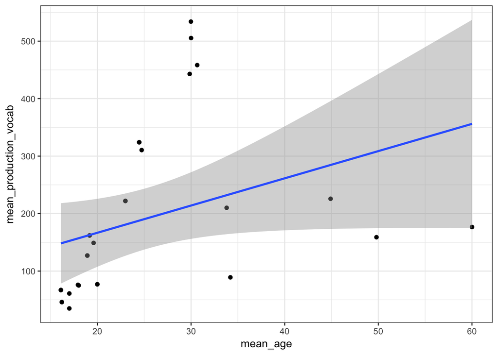

Age and vocab are weakly correlated, not quite significant. Note the heterskadastisky!

Age and vocab vs. effect size

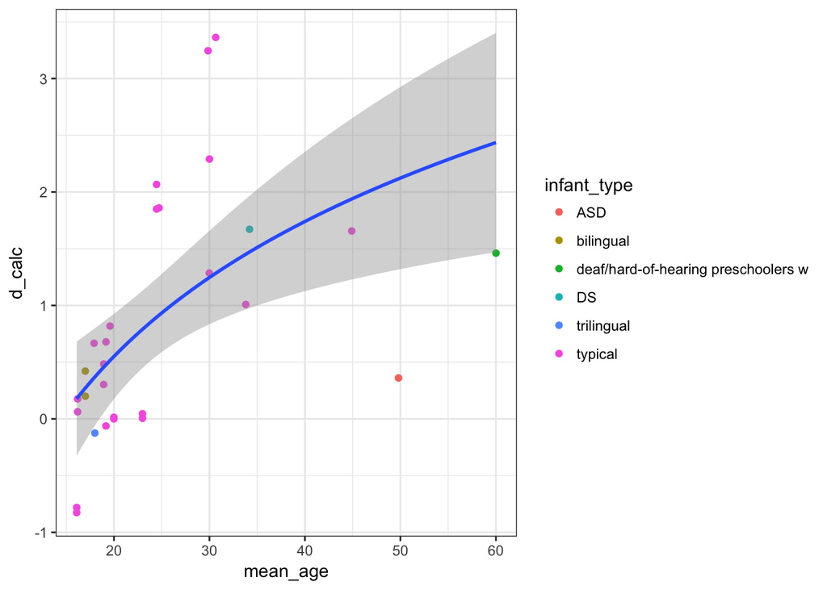

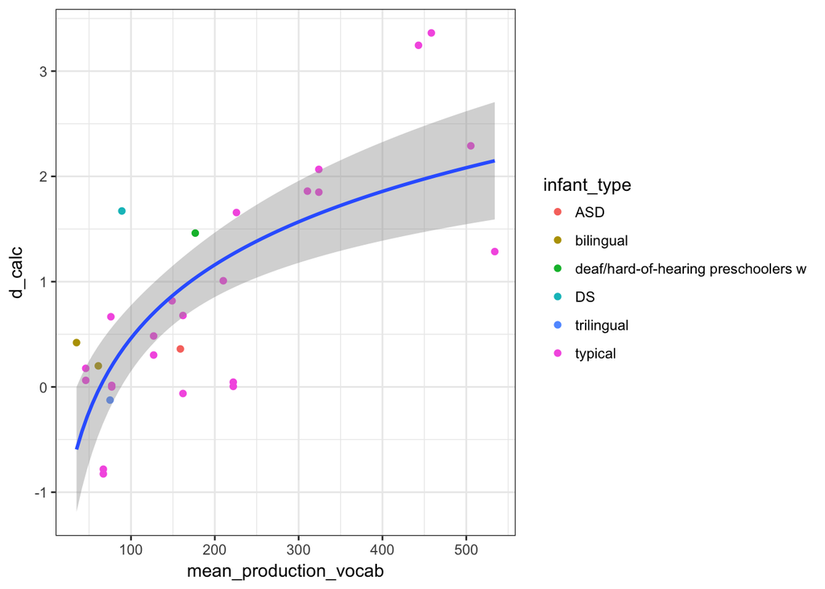

Typical only

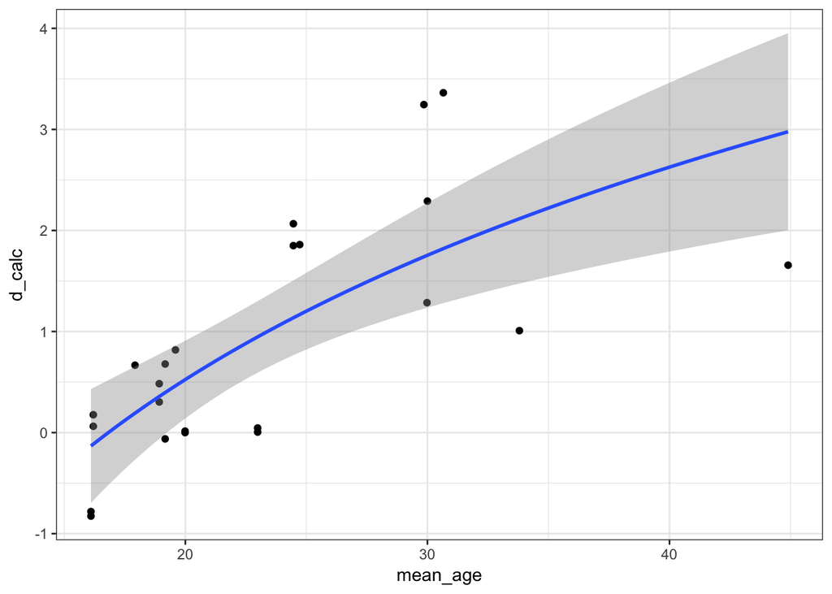

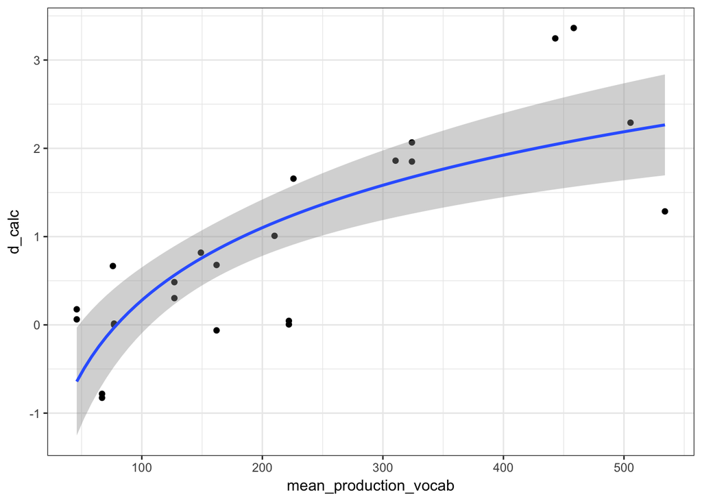

#### Models

```
##
## Multivariate Meta-Analysis Model (k = 29; method: REML)
##
##   logLik  Deviance       AIC       BIC      AICc
## -30.6257   61.2515   67.2515   71.1390   68.2949
##
## Variance Components:
##
##             estim    sqrt  nlvls  fixed      factor
## sigma^2    0.6174  0.7857     11     no  short_cite
##
## Test for Residual Heterogeneity:
## QE(df = 27) = 153.7200, p-val < .0001
##
## Test of Moderators (coefficient(s) 2):
## QM(df = 1) = 1.1347, p-val = 0.2868
##
## Model Results:
##
##           estimate      se    zval    pval    ci.lb   ci.ub
## intrcpt     0.5485  0.4807  1.1410  0.2539  -0.3937  1.4907
## mean_age    0.0155  0.0146  1.0652  0.2868  -0.0130  0.0440
##
## ---
## Signif. codes:  0 '***' 0.001 '**' 0.01 '*' 0.05 '.' 0.1 ' ' 1
```

```
##
## Multivariate Meta-Analysis Model (k = 29; method: REML)
##
##   logLik  Deviance       AIC       BIC      AICc
## -27.8365   55.6730   61.6730   65.5605   62.7165
##
## Variance Components:
##
##             estim    sqrt  nlvls  fixed      factor
## sigma^2    0.4073  0.6382     11     no  short_cite
##
## Test for Residual Heterogeneity:
## QE(df = 27) = 131.2620, p-val < .0001
##
## Test of Moderators (coefficient(s) 2):
## QM(df = 1) = 8.6147, p-val = 0.0033
##
## Model Results:
##
##                        estimate      se    zval    pval    ci.lb   ci.ub
## intrcpt                  0.4909  0.2619  1.8744  0.0609  -0.0224  1.0041
## mean_production_vocab    0.0024  0.0008  2.9351  0.0033   0.0008  0.0039
##
## intrcpt                 .
## mean_production_vocab  **
##
## ---
## Signif. codes:  0 '***' 0.001 '**' 0.01 '*' 0.05 '.' 0.1 ' ' 1
```

```
##
## Multivariate Meta-Analysis Model (k = 29; method: REML)
##
##   logLik  Deviance       AIC       BIC      AICc
## -27.0414   54.0828   62.0828   67.1151   63.9875
##
## Variance Components:
##
##             estim    sqrt  nlvls  fixed      factor
## sigma^2    0.3819  0.6180     11     no  short_cite
##
## Test for Residual Heterogeneity:
## QE(df = 26) = 114.7773, p-val < .0001
##
## Test of Moderators (coefficient(s) 2:3):
## QM(df = 2) = 9.4131, p-val = 0.0090
##
## Model Results:
##
##                        estimate      se    zval    pval    ci.lb   ci.ub
## intrcpt                  0.2672  0.4170  0.6406  0.5218  -0.5502  1.0846
## mean_age                 0.0088  0.0134  0.6549  0.5125  -0.0175  0.0351
## mean_production_vocab    0.0022  0.0008  2.6903  0.0071   0.0006  0.0039
##
## intrcpt
## mean_age
## mean_production_vocab  **
##
## ---
## Signif. codes:  0 '***' 0.001 '**' 0.01 '*' 0.05 '.' 0.1 ' ' 1
```

Typical only:

```
##
## Multivariate Meta-Analysis Model (k = 23; method: REML)
##
##   logLik  Deviance       AIC       BIC      AICc
## -17.1061   34.2122   42.2122   46.1951   44.8789
##
## Variance Components:
##
##             estim    sqrt  nlvls  fixed      factor
## sigma^2    0.5170  0.7190      8     no  short_cite
##
## Test for Residual Heterogeneity:
## QE(df = 20) = 86.1817, p-val < .0001
##
## Test of Moderators (coefficient(s) 2:3):
## QM(df = 2) = 10.2650, p-val = 0.0059
##
## Model Results:
##
##                        estimate      se     zval    pval    ci.lb   ci.ub
## intrcpt                 -0.7825  0.7066  -1.1076  0.2681  -2.1674  0.6023
## mean_age                 0.0705  0.0329   2.1435  0.0321   0.0060  0.1350
## mean_production_vocab    0.0004  0.0012   0.3149  0.7528  -0.0019  0.0027
##
## intrcpt
## mean_age               *
## mean_production_vocab
##
## ---
## Signif. codes:  0 '***' 0.001 '**' 0.01 '*' 0.05 '.' 0.1 ' ' 1
```

With set of conditions with complete production and age, age is not a reliable predictor, vocab is. In model with both, vocab is reliable. But for subset of typical participants, age but not vocab is predictive.

## Misc MA summary stats (for typical only)

Some evidence for a relationship between effect size and sample size: smaller ES, bigger ns (residualizing out age and method)

### Sample size and effect size

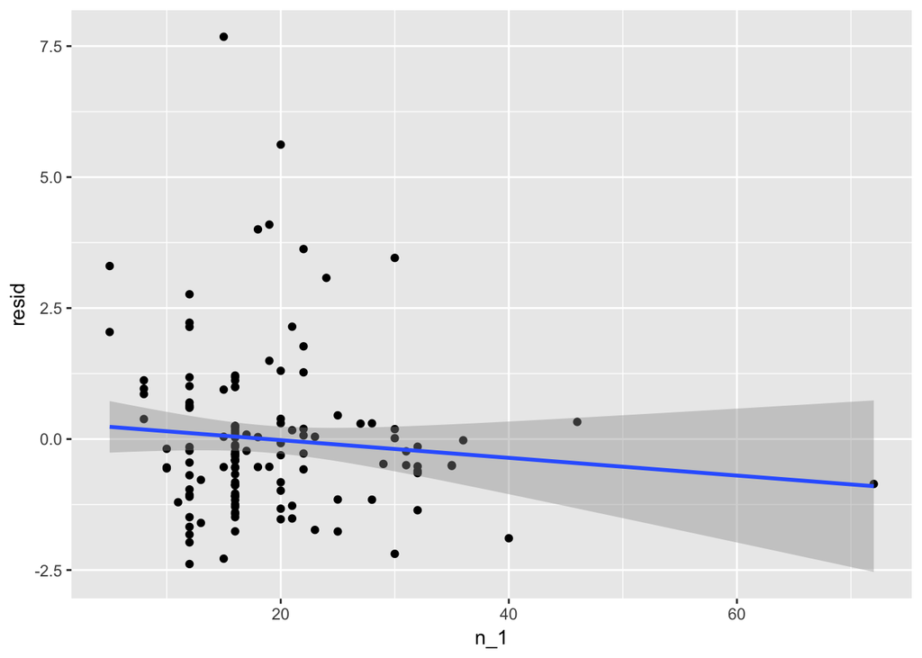

### ME trial type

Controling for age, huge effect of ME_trial_type

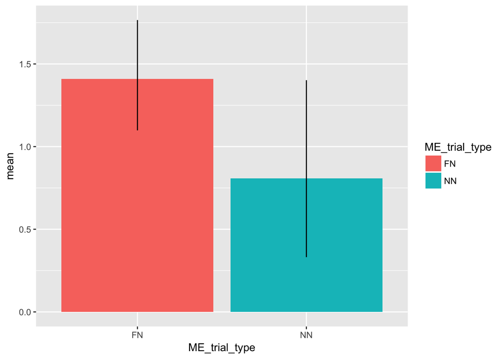

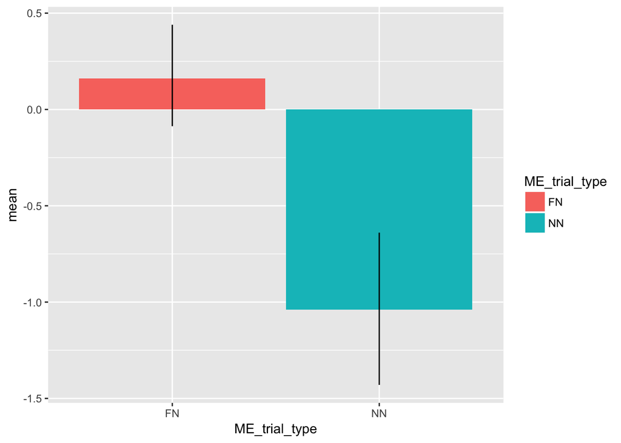

### Stimulus type

No effect

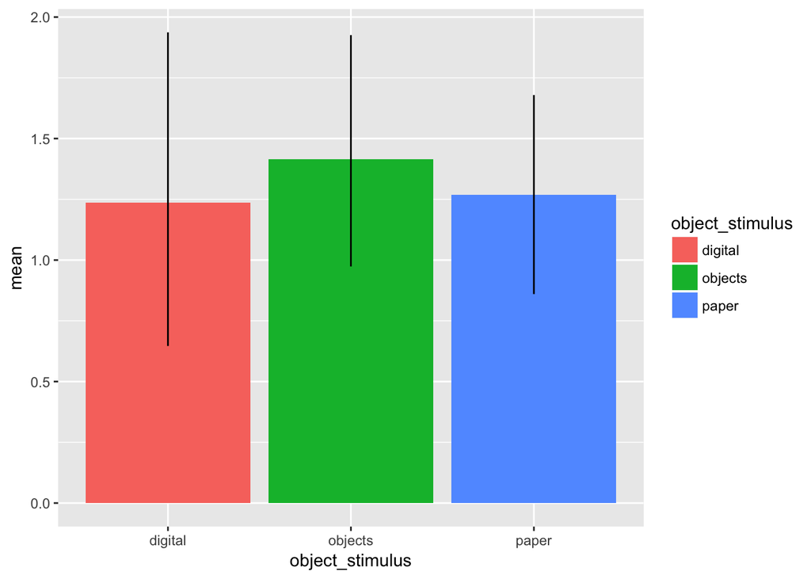

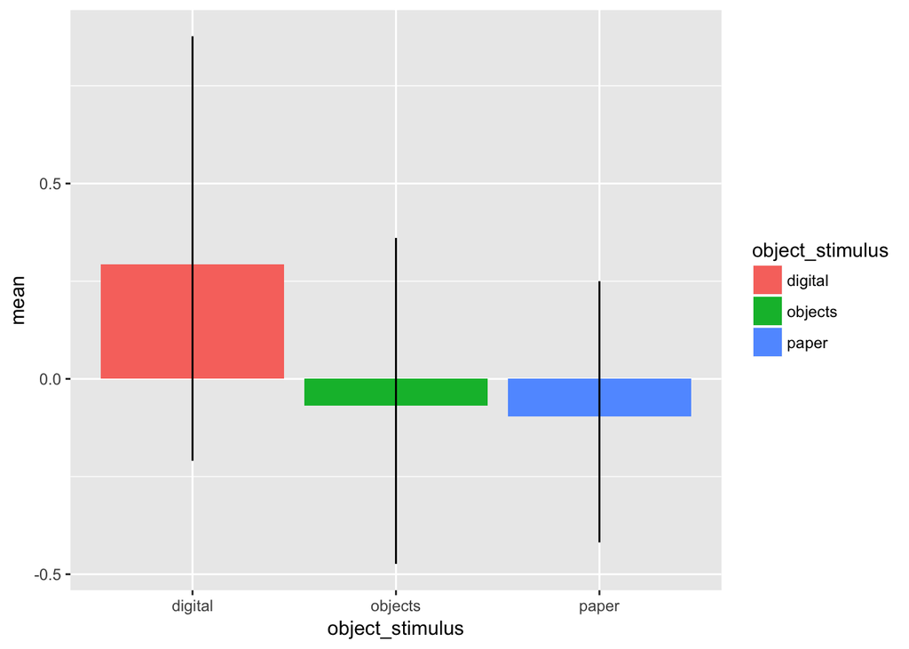

### Lab group

Not interpretable (small sample sizes)

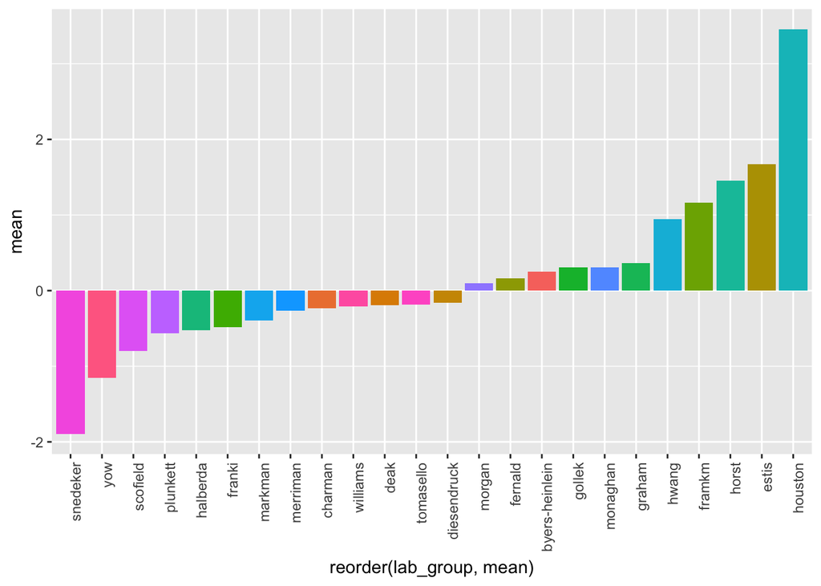

### Time

Effect gets bigger over time, residulaizing out method and age

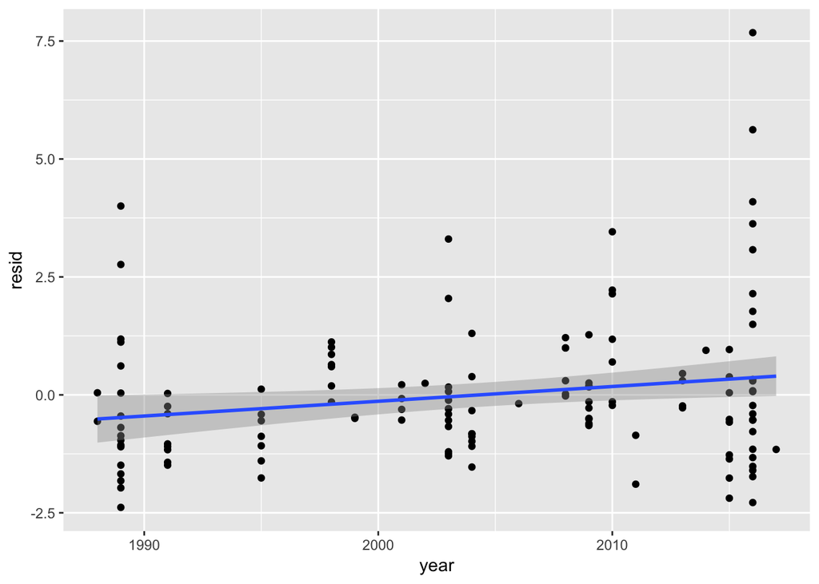

## Mega developmental plot

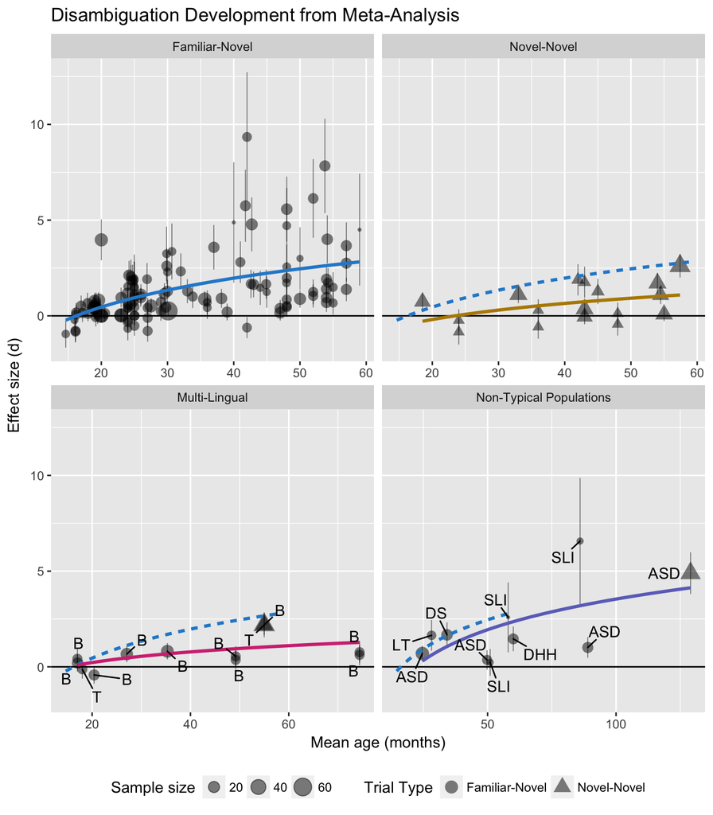